# Getting Started with LundTaxR

Adam Mattsson

2025-10-16

# 1 Introduction

The Lund Taxonomy is a single-sample molecular classification system that divides bladder cancer into distinct subtypes with different clinical behaviors and treatment responses. LundTaxR automates this classification process through:

- **Two-stage classification**: First classifies samples into 5 main subtypes (Uro, GU, BaSq, Mes, ScNE), then sub-classifies Uro samples into UroA, UroB, or UroC
- **Comprehensive molecular profiling**: Calculates signature scores for immune infiltration, stromal content, cell proliferation, and progression risk
- **Advanced visualizations**: Generates publication-ready heatmaps and plots
- **Robust data handling**: Supports multiple gene ID formats and includes missing data imputation

# 2 Input Data Requirements

LundTaxR expects **gene expression data** in matrix or data frame format where: - **Rows** = genes (HGNC symbols or Ensembl IDs) - **Columns** = samples  
- **Values** = expression counts (RNA-seq) or intensities (microarray) - **Format** = Raw counts, TPM, FPKM, or normalized data - **Missing data** = Automatically handled through imputation

The classifier works with both bulk RNA-seq and microarray platforms, requiring a minimum of ~200 overlapping genes from the signature gene sets for reliable classification.

## 2.1 Bundled Test Data

# 3 Quick Start

## 3.1 Run The Classifier

```r
# Load the bundled test dataset
data("sjodahl_2017")

# Classify bladder cancer samples using LundTaxR
sjodahl_classes <- classify_samples(
  this_data = sjodahl_2017,        # Input: gene expression matrix (genes × samples)
  log_transform = FALSE,           # Data is already log2-transformed
  adjust = TRUE,                   # Apply stable gene normalization (default)
  impute = TRUE,                   # Handle missing genes via imputation (default)
  include_data = TRUE,             # Include original data in output (non-default)
  verbose = FALSE                  # Suppress processing messages (non-default)
)
```

## 3.2 Exploring Classification Results

The `classify_samples()` function returns a comprehensive list object containing multiple components. Let’s explore the different types of results and understand what information is available:

```r
# Examine the classification results
summary(sjodahl_classes)
```

```
#>                      Length Class      Mode
#> data                  267   data.frame list
#> subtype_scores       2403   -none-     numeric
#> predictions_7classes  267   -none-     character
#> predictions_5classes  267   -none-     character
#> scores                 35   data.frame list
#> na_genes                3   data.frame list
```

```r
# View the predicted subtypes
table(sjodahl_classes$predictions_5classes)  # 5-class system
```

```
#>
#> BaSq   GU  Mes ScNE  Uro
#>   56   54   16   20  121
```

```r
table(sjodahl_classes$predictions_7classes)  # 7-class system
```

```
#>
#> BaSq   GU  Mes ScNE UroA UroB UroC
#>   56   54   16   20   43   27   51
```

```r
# Access prediction confidence scores
head(sjodahl_classes$subtype_scores)
```

```
#>          Uro   UroA   UroB   UroC     GU   BaSq    Mes   ScNE prediction_delta
#> 1.CEL 0.9924 0.9350 0.0048 0.0602 0.0072 0.0004 0.0000 0.0000           0.0574
#> 2.CEL 0.0016     NA     NA     NA 0.0052 0.0054 0.9804 0.0074           0.9730
#> 3.CEL 0.0682     NA     NA     NA 0.7754 0.0834 0.0390 0.0340           0.6920
#> 4.CEL 0.9930 0.9334 0.0028 0.0638 0.0066 0.0004 0.0000 0.0000           0.0596
#> 5.CEL 0.9808 0.0058 0.9878 0.0064 0.0076 0.0090 0.0006 0.0020           0.0070
#> 6.CEL 0.0082     NA     NA     NA 0.9890 0.0002 0.0004 0.0022           0.9808
```

## 3.3 Creating Publication-Ready Classification Heatmaps

One of LundTaxR’s key strengths is its ability to generate sophisticated heatmaps that visualize both the classification results and the underlying molecular signatures. The `plot_classification_heatmap()` function creates a multi-layered visualization showing:

- **Sample classifications** with color-coded subtype annotations
- **Molecular signatures** including immune infiltration, stromal content, and pathway activity scores
- **Gene expression patterns** for key classifier genes across samples
- **Prediction confidence** through organized sample ordering and score visualization

The heatmap automatically orders samples by subtype and within each subtype by prolfieration score, making it easy to identify patterns and validate classifications. You can choose between 5-class (Uro, GU, BaSq, Mes, ScNE) or 7-class (UroA, UroB, UroC, GU, BaSq, Mes, ScNE) annotation systems.

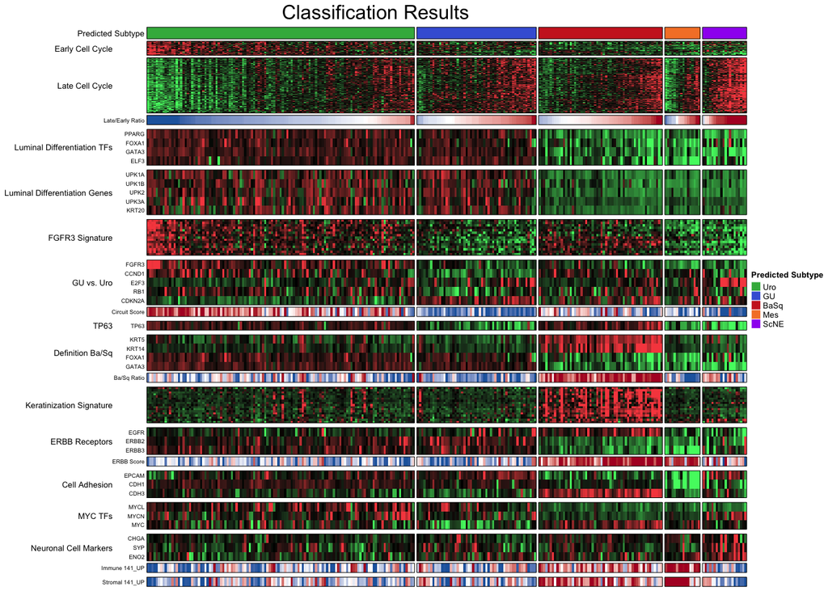

```r
# Create a comprehensive classification heatmap
plot_classification_heatmap(
  these_predictions = sjodahl_classes,              # Classification results from classify_samples()
  subtype_annotation = "5_class",                   # Use 5-class system (Uro, GU, BaSq, Mes, ScNE)
  plot_scores = FALSE,                              # Hide individual prediction scores for cleaner view
  plot_title = "Classification Results",            # Custom title for the visualization
  show_ann_legend = TRUE,                           # Display subtype color legend
  ann_height = 0.5                                  # Compact annotation track height
)
```

```r
# The function displays the heatmap directly in your R session
# To save the plot, add out_path and out_format parameters:
# plot_classification_heatmap(
#   these_predictions = sjodahl_classes,
#   subtype_annotation = "5_class",
#   out_path = "results/",                          # Directory to save plot
#   out_format = "png",                             # File format (png or pdf)
#   plot_title = "Classification_Heatmap",
#   plot_width = 12,                                # Width in inches
#   plot_height = 8                                 # Height in inches
# )
```

The resulting heatmap provides a comprehensive overview of your classification results, with samples grouped by predicted subtype and colored according to their molecular characteristics. This visualization is essential for:

- **Quality assessment**: Verify that samples cluster appropriately within subtypes
- **Pattern recognition**: Identify molecular signatures that distinguish subtypes
- **Publication figures**: Generate high-quality plots ready for manuscripts
- **Result interpretation**: Understand the biological basis of classifications

## 3.4 Visualizing Molecular Signatures with Signature Heatmaps

In addition to classification results, LundTaxR provides detailed molecular profiling through signature scores that capture key biological processes. The `plot_signatures_heatmap()` function creates specialized visualizations focused on these molecular signatures, including:

- **Immune infiltration scores** (B cells, T cells, NK cells, dendritic cells, etc.)
- **Stromal content markers** (CAFs, endothelial cells, smooth muscle)
- **Cellular processes** (proliferation, progression risk, molecular grading)
- **Pathway activities** and other biological signatures

This visualization is particularly valuable for understanding the tumor microenvironment and biological processes that distinguish different bladder cancer subtypes. The heatmap organizes samples by predicted subtype and displays signature scores as color-coded intensities, making it easy to identify subtype-specific molecular patterns.

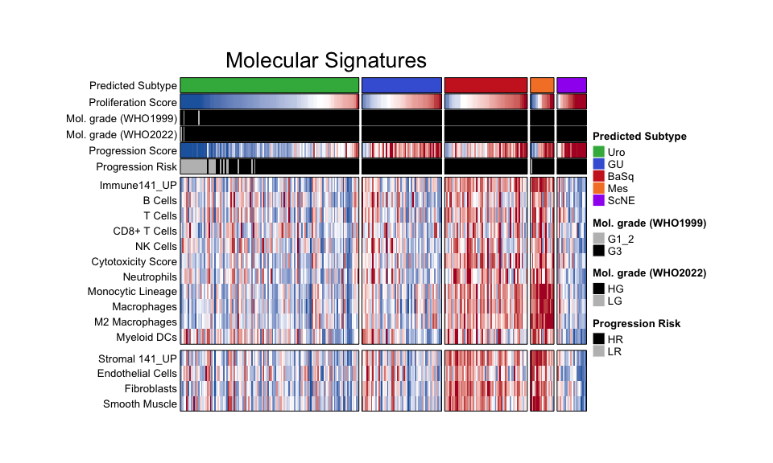

```r
# Create a comprehensive molecular signatures heatmap
plot_signatures_heatmap(
  these_predictions = sjodahl_classes,              # Classification results with signature scores
  proportional_scores = FALSE,                      # Use raw signature scores (not proportions)
  plot_title = "Molecular Signatures",              # Custom title for the visualization
  plot_hm_legend = FALSE,                           # Display heatmap color scale legends
  plot_font_size = 10,                              # Font size for labels and annotations
)
```

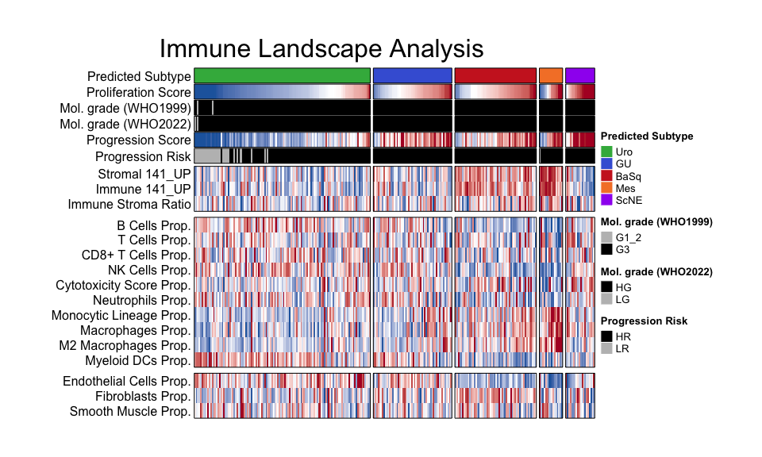

```r
# Alternative: Focus on immune signatures with proportional scoring
plot_signatures_heatmap(
  these_predictions = sjodahl_classes,
  proportional_scores = TRUE,                       # Convert scores to proportions (0-1 scale)
  plot_title = "Immune Landscape Analysis",
  plot_hm_legend = FALSE,
  plot_font_size = 12
)
```

```r
# Save high-quality plot for publication
# plot_signatures_heatmap(
#   these_predictions = sjodahl_classes,
#   out_path = "figures/",                          # Directory to save plot
#   out_format = "pdf",                             # High-resolution PDF format
#   plot_title = "Molecular_Signatures_Heatmap",
#   plot_width = 14,                                # Width in inches for publication
#   plot_height = 10,                               # Height in inches
#   plot_font_size = 8                              # Smaller font for publication
# )
```

### 3.4.1 Understanding the Output

The signature heatmap reveals several key biological insights:

This visualization complements the classification heatmap by focusing on the underlying biological processes that drive subtype differences, providing deeper mechanistic insights into bladder cancer heterogeneity.